# Beijing traffic: relative load, change and duration

The Beijing dataset describes one simulation day on a directed road network. The saved visualization contains 11,742 displayed edges and 288 five-minute frames spanning 00:00 to 24:00. The default frame, 107, covers 08:50 to 08:55 and has the highest saved mean relative load and high-load edge count.

## Source and data preparation

The project document, `个体轨迹数据拥堵溯源分析项目及数据说明.docx`, describes individual vehicle trajectories, link statistics and network inputs. Its `output_agent.csv` and `output_LinkTDMOE.csv` are simulation outputs. `input_node.csv` and `input_link.csv` define the network; node-control and zone files supply additional input attributes.

The saved map is `saturation_dynamic_leaflet_osm_osmgeom.html`. Data preparation copies its nine JSON assignment literals into a compressed JSON file. Geometry, edge IDs, frame order, rounded load values and saved duration records remain unchanged. JSON validation checks each literal. The numeric text remains unchanged, including the original coordinate precision.

```r
source_html <- 'saturation_dynamic_leaflet_osm_osmgeom.html'
source_lines <- readLines(source_html, warn=FALSE, encoding='UTF-8')
keys <- c('network','flowByBin','durationByBin','timeMeta','timeBins',
          'bounds','congestionStops','timeBinMinutes','metricKey')
literal <- function(key) {
  pattern <- paste0('^\\s*const ', key, '\\s*=\\s*')
  candidates <- sub(';\\s*$', '', sub(pattern, '',
                    grep(pattern, source_lines, value=TRUE)))
  candidates <- candidates[vapply(candidates, jsonlite::validate, logical(1))]
  stopifnot(length(candidates)==1L)
  candidates
}
payload <- paste(paste0('"',keys,'":',vapply(keys,literal,'')),collapse=',')
provenance <- jsonlite::toJSON(list(source_html=basename(source_html),
  source_md5=unname(tools::md5sum(source_html))),auto_unbox=TRUE)
artifact <- paste0('{"schema_version":1,"source":"beijing","provenance":',
                   provenance,',"payload":{',payload,'}}')
output_file <- 'data/beijing-visualization.json.gz'
stopifnot(!file.exists(output_file))
dir.create(dirname(output_file), recursive=TRUE, showWarnings=FALSE)
con <- gzfile(output_file, 'wt')
tryCatch(writeLines(artifact, con, useBytes=TRUE), finally=close(con))
```

This preparation stage is separate from report rendering. The report reads `data/beijing-visualization.json.gz`.

The bundled `bdynets_0.1.0.tar.gz` supplies the version 0.1.0 source package, including its license. The report setup and `run.R` use an installed package when available; otherwise they install the bundled source into a temporary library for that R session. The package depends on `magrittr` in addition to standard R libraries. R Markdown rendering uses `jsonlite`, `rmarkdown`, `knitr` and Pandoc. The preparation code creates its output directory and refuses to overwrite an existing dataset.

| Original processing code | Contribution to the saved map |
| --- | --- |
| `process_real_traffic_data.py` | Converts local coordinates using fixed calibration coefficients, expands directed links and counts completed-agent occupancy in overlapping five-minute bins. PCE weighting is disabled. |
| `estimate_xijt_capacity.py` | Estimates an empirical count denominator by quantile gradient boosting, bounded below by the edge maximum and one. |
| `match_osm_geometry.py`, `route_osm_geometry.py` | Obtain OSM geometry and construct routed display polylines. |
| `visualize_real_network.py` | Combines counts, capacity and geometry; saves relative load and duration; excludes edges without display geometry. |

## Saved fields

```r
snapshot <- read_traffic_data(params$snapshot)
stopifnot(snapshot$source=='beijing', length(snapshot$bins)==288L,
          snapshot$bin_minutes==5L,
          snapshot$time_meta[[as.character(snapshot$bins[1])]]$start_min==0,
          snapshot$time_meta[[as.character(tail(snapshot$bins,1))]]$end_min==1440)
knitr::kable(data.frame(edges=length(snapshot$ids), frames=length(snapshot$bins),
                       minutes_per_frame=snapshot$bin_minutes))
```

| edges | frames | minutes_per_frame |
| --- | --- | --- |
| 11742 | 288 | 5 |

| Field | Definition |
| --- | --- |
| `network` | Directed edge IDs and saved routed polylines. |
| `flowByBin` | Sparse relative load, `x_ijt / estimated capacity`, rounded to three decimals. |
| `durationByBin` | Consecutive high-load duration in five-minute bins. |
| `timeBins`, `timeMeta` | Frame order, interval boundaries and saved frame summaries. |
| `congestionStops` | Relative-load color classes at 0%, 20%, 40%, 60% and 80%+. |
| `timeBinMinutes`, `metricKey` | Five-minute spacing and the `saturation` metric identifier. |

Sparse entries absent from a frame follow the viewer’s zero convention. Relative load is a ratio to an estimated count denominator. It is distinct from observed speed, accident frequency or a congestion probability.

## Relative load, change and duration

```r
frames <- traffic_osm_figures(params$snapshot, 'beijing',
                          time_index=params$time_index)
```

[figure not shown]

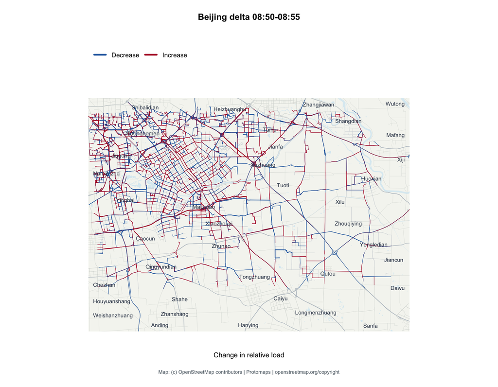

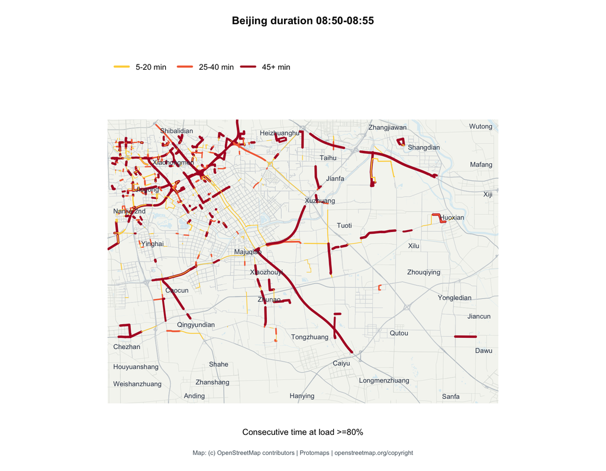

The source applies the 80% duration threshold before rounding display values. Consequently, a displayed value of 0.800 can differ from a classification recomputed from rounded values. The duration map uses the saved records. The maps retain routed polylines and Web Mercator projection. Static line widths differ from browser widths. Cached OSM-derived roads and water provide geographic context; browser controls are absent.

## Selected-frame statistics

```r
statistics <- unlist(frames$current$summary)
knitr::kable(data.frame(statistic=names(statistics), value=unname(statistics)))
```

| statistic | value |
| --- | --- |
| start_min | 530.0000 |
| end_min | 535.0000 |
| active_edges | 7409.0000 |
| active_share | 0.6310 |
| congested_edges | 615.0000 |
| congested_share | 0.0524 |
| total_xijt | 352776.0000 |
| mean_metric | 0.3120 |
| p95_metric | 0.8850 |
| max_metric | 1.0000 |

`active_edges` counts positive displayed loads. `congested_edges` is the saved high-load count based on the source threshold. `total_xijt` sums edge-bin occupancy counts, so an agent present on several edges or bins contributes several times. `mean_metric`, `p95_metric` and `max_metric` summarize relative load. At the selected interval the saved mean is 0.312 and the high-load count is 615.

## Offline geographic context

`osm-figures.R` draws the saved traffic frames over `data/osm-basemap.json.gz`. `download_osm.py` records the cache preparation: zoom-11 `roads`, `water` and `places` layers from the Protomaps archive dated 20 October 2026, covering the saved map bounds with a 0.02-degree margin. The cache contains the source URL, retrieval time, individual tile hashes and a checksum of the extracted geometry. Preparation depends on Python packages `requests`, `pmtiles` and `mapbox-vector-tile`; rendering reads the local cache without network requests.

The background is a generalized contemporary OSM extract. It supplies spatial context without changing traffic geometry, values, colors or connectivity. Available English place labels are thinned for readability. The basemap is not a reconstruction of the road network on the traffic observation date. Map data: [OpenStreetMap contributors](https://www.openstreetmap.org/copyright), via [Protomaps](https://docs.protomaps.com/basemaps/downloads), ODbL Produced Work.

## Frame selection and export

The `time_index` parameter addresses the day’s 288 frames using R’s one-based index. Frame 97 is 08:00 to 08:05. The same plotting function supports a selected-frame export:

```r
traffic_osm_figures(params$snapshot, 'beijing', time_index=97L,
                output_dir='output/beijing-0800')
```

Exports contain three PDF and PNG figures, input identity and a selection record. The HTML contains the figures directly. R dependencies are `bdynets`, `jsonlite`, `rmarkdown` and `knitr`; HTML rendering also depends on Pandoc.

## Interpretation

These maps describe simulated relative load. Agent-level congestion tracing also depends on node/time sequence alignment, directed-edge joins and temporal overlap rules. The original preprocessing truncates unequal path and time sequences to their common length, skips invalid intervals and excludes unmatched traversals. Display geometry excludes some edges from the plotted network. These choices affect which agents and links remain available for tracing. Rounded ratios cannot replace raw counts, exposure or a validated congestion model.